# PEC 2 REGRESION

#### (c) Con los 38 datos restantes, hallar el “mejor” modelo consensuado por dos métodos diferentes de selección de variables como, por ejemplo, R2 adj y Cp de Mallows.

##### Empezamos con el R2 adj como criterio de selección

```r
library(leaps)
b <- regsubsets(Systol~Age+Years+Weight+Height+Chin+Forearm+Calf+Pulse+fraction_urban, data=data_peru_bueno)
rs <- summary(b)
rs$outmat
```

```
##          Age Years Weight Height Chin Forearm Calf Pulse fraction_urban
## 1  ( 1 ) " " " "   "*"    " "    " "  " "     " "  " "   " "
## 2  ( 1 ) " " " "   "*"    " "    " "  " "     " "  " "   "*"
## 3  ( 1 ) "*" "*"   " "    " "    " "  " "     " "  " "   "*"
## 4  ( 1 ) "*" "*"   "*"    " "    " "  " "     " "  " "   "*"
## 5  ( 1 ) "*" "*"   "*"    " "    " "  "*"     " "  " "   "*"
## 6  ( 1 ) "*" "*"   "*"    "*"    " "  "*"     " "  " "   "*"
## 7  ( 1 ) "*" "*"   "*"    "*"    "*"  "*"     " "  " "   "*"
## 8  ( 1 ) "*" "*"   "*"    "*"    "*"  "*"     "*"  " "   "*"
```

```r
k<-length(rs$rss)
p<-k+1

rs$adjr2
```

```
## [1] 0.2213449 0.4180425 0.4416393 0.5618138 0.6150372 0.6181600 0.6295699
## [8] 0.6230287
```

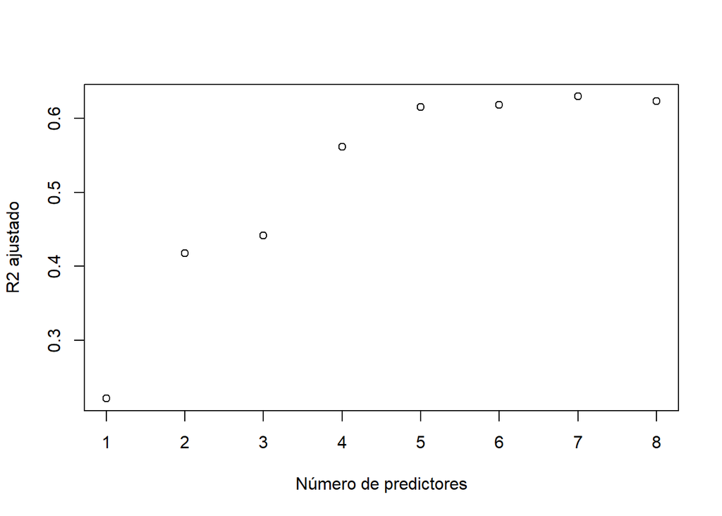

```r
plot(1:k,rs$adjr2, xlab="Número de predictores", ylab="R2 ajustado", axes = F)
box(); axis(1,at=1:k); axis(2)
```

```r
# Encontramos el valor óptimo de R2 con 7 predictores, no obstante con cinco predictores es muy parecido.
```

##### Y probamos ahora con el Cp de Mallows como criterio de selección

```r
rs$cp
```

```
## [1] 38.295709 20.532028 18.961941  9.293879  5.771204  6.528675  6.661067
## [8]  8.194940
```

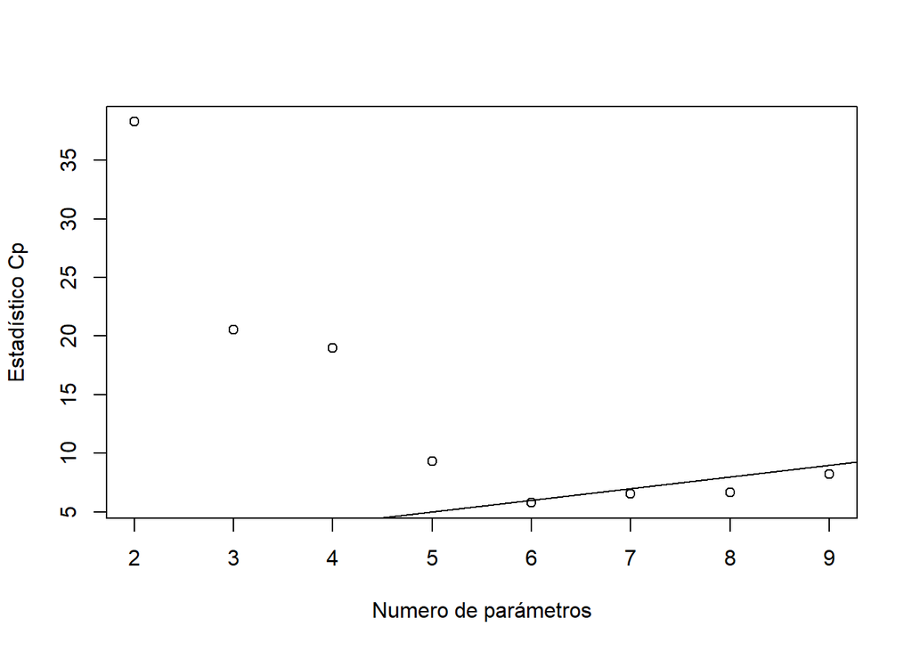

```r
plot(2:p,rs$cp, xlab="Numero de parámetros", ylab="Estadístico Cp", axes = F)
box(); axis(1,at=2:p); axis(2)
abline(a=0,b=1) #El mejor valor, el mínimo Cp, se alcanza con 5 predictores (6 parámetros).
```

#### (i) ¿Cuales son las variables seleccionadas?

```r
#Viendo los resultados de R2 y Cp, lo mejor es un modelo con 5 predictores, estos serían:
rs$outmat[5,] #Age, Years, Weight, Forearm y fraction_urban
```

```
##            Age          Years         Weight         Height           Chin
##            "*"            "*"            "*"            " "            " "
##        Forearm           Calf          Pulse fraction_urban
##            "*"            " "            " "            "*"
```

#### (ii) ¿Cual es el coeficiente de determinación ajustado de este modelo? Compararlo con el del modelo completo.

```r
lm_systol_bueno<-lm(Systol~Age+Years+Weight+Height+Chin+Forearm+Calf+Pulse+fraction_urban, data=data_peru_bueno)
summary(lm_systol_bueno) #Este sería el modelo completo con todas las variables, donde son significativas Age, Years, Weight, Forearm y fraction_urban, con un p-valor de 0.1 o inferior. El R2 es 0.7066
```

```
##
## Call:
## lm(formula = Systol ~ Age + Years + Weight + Height + Chin +
##     Forearm + Calf + Pulse + fraction_urban, data = data_peru_bueno)
##
## Residuals:
##      Min       1Q   Median       3Q      Max
## -12.1497  -4.1489  -0.2525   5.2688  16.7433
##
## Coefficients:
##                  Estimate Std. Error t value Pr(>|t|)
## (Intercept)     166.35727   46.12801   3.606 0.001194 **
## Age              -1.18974    0.30488  -3.902 0.000546 ***
## Years             3.02918    0.79227   3.823 0.000673 ***
## Weight            1.65662    0.41220   4.019 0.000399 ***
## Height           -0.05052    0.03481  -1.451 0.157876
## Chin             -0.94857    0.68696  -1.381 0.178257
## Forearm          -2.38282    1.21649  -1.959 0.060168 .
## Calf              0.38367    0.54705   0.701 0.488874
## Pulse             0.07024    0.15909   0.442 0.662228
## fraction_urban -145.53620   30.68660  -4.743  5.6e-05 ***
## ---
## Signif. codes:  0 '***' 0.001 '**' 0.01 '*' 0.05 '.' 0.1 ' ' 1
##
## Residual standard error: 8.025 on 28 degrees of freedom
## Multiple R-squared:  0.7066, Adjusted R-squared:  0.6123
## F-statistic: 7.492 on 9 and 28 DF,  p-value: 1.696e-05
```

```r
lm_systol_bueno_red<-lm(Systol~Age+Years+Weight+Forearm+fraction_urban, data=data_peru_bueno)
summary(lm_systol_bueno_red) #Y este el modelo con las 5 variables que elegimos. El R2 es de 0.6671, algo más bajo que el modelo completo pero el cambio es muy leve.
```

```
##
## Call:
## lm(formula = Systol ~ Age + Years + Weight + Forearm + fraction_urban,
##     data = data_peru_bueno)
##
## Residuals:
##     Min      1Q  Median      3Q     Max
## -14.162  -5.498   0.333   5.539  15.894
##
## Coefficients:
##                 Estimate Std. Error t value Pr(>|t|)
## (Intercept)     116.6799    20.0133   5.830 1.78e-06 ***
## Age              -1.2035     0.3024  -3.980 0.000371 ***
## Years             3.2951     0.7724   4.266 0.000165 ***
## Weight            1.1624     0.2817   4.126 0.000245 ***
## Forearm          -1.7233     0.7307  -2.358 0.024623 *
## fraction_urban -153.2570    30.1142  -5.089 1.53e-05 ***
## ---
## Signif. codes:  0 '***' 0.001 '**' 0.01 '*' 0.05 '.' 0.1 ' ' 1
##
## Residual standard error: 7.996 on 32 degrees of freedom
## Multiple R-squared:  0.6671, Adjusted R-squared:  0.615
## F-statistic: 12.82 on 5 and 32 DF,  p-value: 6.991e-07
```

#### (iii) ¿Se gana en eficiencia con el modelo reducido? Comparar los intervalos de confianza de la estimación del coeficiente de la variable Age.

##### El siguiente paso sería contrastar si el modelo reducido es intercambiable con el completo. Como vemos, ambos valores de R2 son muy similares, pero habrá que ver con una ANOVA si son equivalentes. La H0 es que todos los parámetros de los predictores que hemos eliminado del modelo son cero.

```r
anova(lm_systol_bueno,lm_systol_bueno_red) #Como podemos observar, el p-valor obtenido es de 0.4539, superior a 0.05. La diferencia entre ambos modelos no es significativa. Por simplicidad y comodidad, podemos utilizar el modelo reducido.
```

```
## Analysis of Variance Table
##
## Model 1: Systol ~ Age + Years + Weight + Height + Chin + Forearm + Calf +
##     Pulse + fraction_urban
## Model 2: Systol ~ Age + Years + Weight + Forearm + fraction_urban
##   Res.Df    RSS Df Sum of Sq      F Pr(>F)
## 1     28 1803.0
## 2     32 2045.8 -4   -242.84 0.9428 0.4539
```

##### Y ahora vamos a comparar los I.C. de la estimación del coeficiente de la variable Age.

```r
confint(lm_systol_bueno) #Con el modelo completo el I.C. para la variable Age es (-1.8142681, -0.56522175)
```

```
##                       2.5 %       97.5 %
## (Intercept)      71.8683281 260.84620905
## Age              -1.8142681  -0.56522175
## Years             1.4062872   4.65207036
## Weight            0.8122712   2.50097753
## Height           -0.1218283   0.02079582
## Chin             -2.3557476   0.45860437
## Forearm          -4.8746857   0.10904896
## Calf             -0.7369032   1.50424248
## Pulse            -0.2556352   0.39611568
## fraction_urban -208.3948497 -82.67754163
```

```r
confint(lm_systol_bueno_red) #Y con el modelo reducido el I.C. para la variable Age es (-1.8194498  -0.5875311)
```

```
##                       2.5 %      97.5 %
## (Intercept)      75.9141964 157.4455178
## Age              -1.8194498  -0.5875311
## Years             1.7218386   4.8684563
## Weight            0.5885264   1.7361884
## Forearm          -3.2116541  -0.2349512
## fraction_urban -214.5975248 -91.9164499
```

```r
#Son extremadamente similares.
```

#### (d) Los investigadores sugieren adoptar el modelo reducido que contenga únicamente las variables significativas (α = 0.1) con el test t en sustitución del modelo completo con las 9 variables explicativas.¿Es ese un buen criterio de selección? Realizar un test adecuado que resuelva su sugerencia. Discutir el resultado en consonancia con los resultados obtenidos en el apartado anterior.

##### Si nos fijamos en el apartado anterior, cuando elegimos el modelo reducido en base a los criterios de R2 ajustado y Cp de Mallows, nos quedamos solamente con aquellas variables que justo eran significativas a un valor de α = 0.1 o inferior. Con el test de ANOVA vimos que ambos modelos pueden usarse sin que se vea significativamente afectado la bondad del modelo para explicar la presión sistólica en la población estudiada. Por eso, sí sería un buen criterio de selección considerar incluir aquellas variables por encima de 0.1.

#### (e) Comprobar si hemos solucionado el problema de multicolinealidad en el modelo reducido del apartado anterior.

##### Vamos a repetir lo mismo que hicimos antes para estudiar si existe multicolinealidad en el modelo reducido.

```r
summary(lm_systol_bueno_red) #Recordamos cómo era el modelo reducido
```

```
##
## Call:
## lm(formula = Systol ~ Age + Years + Weight + Forearm + fraction_urban,
##     data = data_peru_bueno)
##
## Residuals:
##     Min      1Q  Median      3Q     Max
## -14.162  -5.498   0.333   5.539  15.894
##
## Coefficients:
##                 Estimate Std. Error t value Pr(>|t|)
## (Intercept)     116.6799    20.0133   5.830 1.78e-06 ***
## Age              -1.2035     0.3024  -3.980 0.000371 ***
## Years             3.2951     0.7724   4.266 0.000165 ***
## Weight            1.1624     0.2817   4.126 0.000245 ***
## Forearm          -1.7233     0.7307  -2.358 0.024623 *
## fraction_urban -153.2570    30.1142  -5.089 1.53e-05 ***
## ---
## Signif. codes:  0 '***' 0.001 '**' 0.01 '*' 0.05 '.' 0.1 ' ' 1
##
## Residual standard error: 7.996 on 32 degrees of freedom
## Multiple R-squared:  0.6671, Adjusted R-squared:  0.615
## F-statistic: 12.82 on 5 and 32 DF,  p-value: 6.991e-07
```

```r
#Estudiamos los números de condición
X2<-model.matrix(lm_systol_bueno_red)
va2<-eigen(t(X2) %*% X2)$values
sqrt(max(va2)/va2)  #Vemos que sí hay tres números de condición > 30. Por ello, vamos a ver los factores de inflación de la varianza a ver si el problema de multicolinealidad es grande.
```

```
## [1]    1.000000    8.240483   14.034478   39.021891  787.431012 1953.077392
```

```r
#Factores de inflacción de la varianza
vif(lm_systol_bueno_red) #Vemos que seguimos teniendo valores muy altos como los de Years y fraction_urban.
```

```
##            Age          Years         Weight        Forearm fraction_urban
##       3.105001      35.118905       2.245658       1.665539      24.738540
```

```r
#Aunque algo ha mejorado, seguimos teniendo problemas de multicolinealidad también en el modelo reducido.
```

#### Como los investigadores no quieren prescindir de más variables, se plantea una regresión Partial Least Squares (PLS). ¿Cuantas componentes se necesitan para minimizar el RMSEP? Calcular los coeficientes de las variables originales, también para β0, que proporciona este método con el número de componentes necesario.

##### Dado que sigue existiendo el problema de multicolinealidad, vamos a ver cuántos componentes del análisis de componentes principales son necesarios para minimizar el RMSE

```r
library(pls)
```

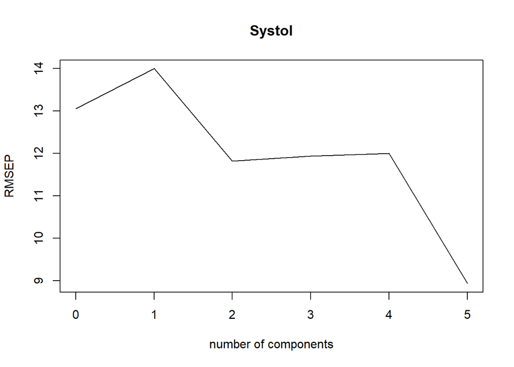

```r
set.seed(222)
pls_peru <- plsr(Systol ~ Age + Years + Weight + Forearm + fraction_urban, data = data_peru_bueno, validation = "CV")
peruCV<-RMSEP(pls_peru, estimate="CV")
plot(peruCV)
```

```r
which.min(peruCV$val) #Obtenemos que el número mínimo de componentes es de 6, pero realmente serían 5 ya que el primer valor es para el intercept (0).
```

```
## [1] 6
```

##### Calculamos los coeficientes

```r
pls_peru_5<-plsr(Systol ~ Age + Years + Weight + Forearm + fraction_urban, data = data_peru_bueno, ncomp = 5)
coef(pls_peru_5, intercept = TRUE) #Aquí tenemos los coef. de las variables originales y del intercept (β0)
```

```
## , , 5 comps
##
##                     Systol
## (Intercept)     116.679857
## Age              -1.203490
## Years             3.295147
## Weight            1.162357
## Forearm          -1.723303
## fraction_urban -153.256987
```

#### ¿Es adecuado este método de regresión con estas variables? ¿Es útil?

```r
summary(lm_systol_bueno_red) #Vemos que los coeficientes obtenidos por PLS arriba respecto al modelo anterior reducido (que incluía las variables con alfa ≤ 0.01) son prácticamente iguales.
```

```
##
## Call:
## lm(formula = Systol ~ Age + Years + Weight + Forearm + fraction_urban,
##     data = data_peru_bueno)
##
## Residuals:
##     Min      1Q  Median      3Q     Max
## -14.162  -5.498   0.333   5.539  15.894
##
## Coefficients:
##                 Estimate Std. Error t value Pr(>|t|)
## (Intercept)     116.6799    20.0133   5.830 1.78e-06 ***
## Age              -1.2035     0.3024  -3.980 0.000371 ***
## Years             3.2951     0.7724   4.266 0.000165 ***
## Weight            1.1624     0.2817   4.126 0.000245 ***
## Forearm          -1.7233     0.7307  -2.358 0.024623 *
## fraction_urban -153.2570    30.1142  -5.089 1.53e-05 ***
## ---
## Signif. codes:  0 '***' 0.001 '**' 0.01 '*' 0.05 '.' 0.1 ' ' 1
##
## Residual standard error: 7.996 on 32 degrees of freedom
## Multiple R-squared:  0.6671, Adjusted R-squared:  0.615
## F-statistic: 12.82 on 5 and 32 DF,  p-value: 6.991e-07
```

```r
#Además, tenemos el mismo número de variables, no se han reducido, siguen siendo 5. No veo mucha utilidad a este modelo teniendo el anterior, ni mucha mejora al usarlo. También seguimos teniendo el problema de la multicolinealidad.
```

#### (f) Siguiendo con el modelo reducido, otra posibilidad es utilizar la Ridge Regression. ¿Cuales son los coeficientes obtenidos? Explicar brevemente las ventajas e inconvenientes de este método frente a la selección de variables.

##### Vamos a utilizar la Ridge Regression y ver las ventajas e inconvenientes

```r
library(MASS)
ridge_peru <- lm.ridge(Systol ~ Age + Years + Weight + Forearm + fraction_urban, data = data_peru_bueno, lambda = seq(0, 10, 0.0001))
lambda <- which.min(ridge_peru$GCV)
select(ridge_peru)
```

```
## modified HKB estimator is 0.08281436
## modified L-W estimator is 1.778106
## smallest value of GCV  at 0.0331
```

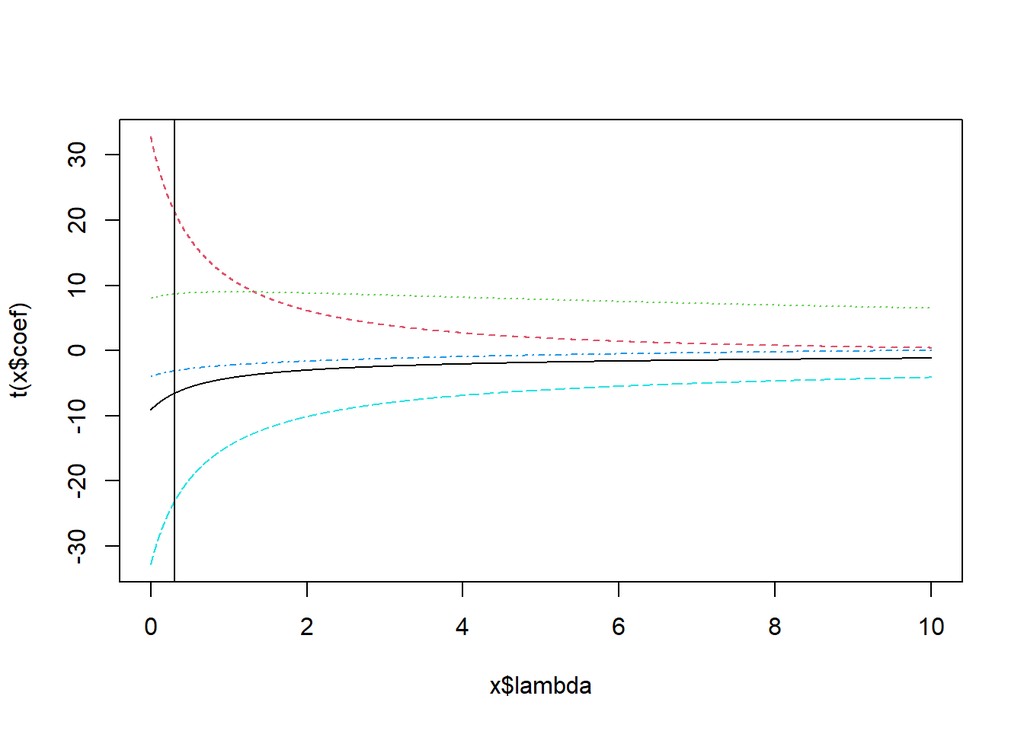

```r
plot(ridge_peru)
abline(v=0.3)
```

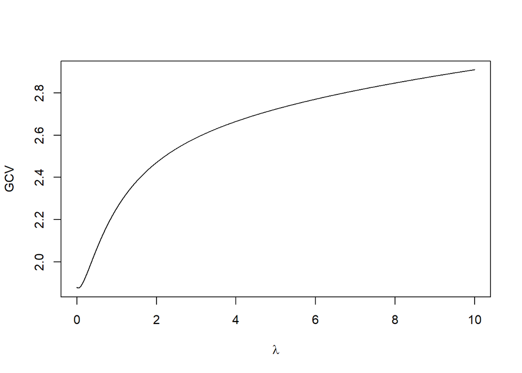

```r
plot(ridge_peru$lambda,ridge_peru$GCV,type="l",xlab=expression(lambda),ylab="GCV")
abline(v=lambda,col=2)
```

```r
#Vemos que el valor más pequeño de GCV es 0.0331, por lo que estableceremos λ=0.03 como valor de lambda óptimo.

set.seed(2222)
ridge_peru_003 <- lm.ridge(Systol ~ Age + Years + Weight + Forearm + fraction_urban, data = data_peru_bueno, lambda = 0.03)
```

```r
coef(ridge_peru_003, intercept = TRUE) #Para λ=0.03 estos son los coeficientes. Vemos que se han reducido levemente respecto al modelo con las 5 variables que tienen un alfa ≤ 0.01.
```

```
##                           Age          Years         Weight        Forearm
##     113.772709      -1.156289       3.132749       1.176816      -1.674308
## fraction_urban
##    -146.940408
```

##### ventajas e inconvenientes de este modelo Ridge Regression frente a la selección de variables:

- Ventajas: permite mejorar los errores de predicción al reducir el valor de los coeficientes, tal y como hemos observado arriba. Así, evitamos que sean muy grandes y reducimos el sobreajuste.
- Inconvenientes: no realiza selección de variables, seguimos teniendo los mismo 5 predictores (no elimina las menos influyentes).

#### Calcular el RMSE de la regresión OLS, PLS (con 5, 4, 3 y 2 componentes) y Ridge (con λ óptima por GCV) para el modelo reducido.

##### Ahora calculamos el error cuadrático medio (RMSE) de la regresión Ordinary Least Squares (OLS)

```r
RSS.ols<-c(crossprod(lm_systol_bueno_red$residuals))
MSE.ols<-RSS.ols/length(lm_systol_bueno_red$residuals)
RMSE.ols<-sqrt(MSE.ols)
RMSE.ols #Sería este valor, 7.337436
```

```
## [1] 7.337436
```

##### Y a continuación el el error cuadrático medio (RMSE) para los PLS con distintos números de componentes

```r
pls_peru_5<-plsr(Systol ~ Age + Years + Weight + Forearm + fraction_urban, data = data_peru_bueno, ncomp = 5)
pls_peru_5$coefficients
```

```
## , , 1 comps
##
##                     Systol
## Age            -0.10339839
## Years          -0.16490689
## Weight          1.14904659
## Forearm         0.20717441
## fraction_urban -0.01507042
##
## , , 2 comps
##
##                     Systol
## Age            -0.24195873
## Years          -0.42894308
## Weight          1.29914221
## Forearm         0.22028353
## fraction_urban -0.02477824
##
## , , 3 comps
##
##                     Systol
## Age            -0.08156508
## Years          -0.54508847
## Weight          1.35653895
## Forearm         0.03786032
## fraction_urban -0.04613225
##
## , , 4 comps
##
##                    Systol
## Age            -0.1841884
## Years          -0.5176248
## Weight          1.5122684
## Forearm        -0.6366994
## fraction_urban -0.1211482
##
## , , 5 comps
##
##                     Systol
## Age              -1.203490
## Years             3.295147
## Weight            1.162357
## Forearm          -1.723303
## fraction_urban -153.256987
```

```r
RSS.pls5<-c(crossprod(pls_peru_5$residuals))
MSE.pls5<-RSS.pls5/length(pls_peru_5$residuals)
RMSE.pls5<-sqrt(MSE.pls5)
RMSE.pls5 #Para 5 componentes valdría 9.586971
```

```
## [1] 9.586971
```

```r
pls_peru_4<-plsr(Systol ~ Age + Years + Weight + Forearm + fraction_urban, data = data_peru_bueno, ncomp = 4)
pls_peru_4$coefficients
```

```
## , , 1 comps
##
##                     Systol
## Age            -0.10339839
## Years          -0.16490689
## Weight          1.14904659
## Forearm         0.20717441
## fraction_urban -0.01507042
##
## , , 2 comps
##
##                     Systol
## Age            -0.24195873
## Years          -0.42894308
## Weight          1.29914221
## Forearm         0.22028353
## fraction_urban -0.02477824
##
## , , 3 comps
##
##                     Systol
## Age            -0.08156508
## Years          -0.54508847
## Weight          1.35653895
## Forearm         0.03786032
## fraction_urban -0.04613225
##
## , , 4 comps
##
##                    Systol
## Age            -0.1841884
## Years          -0.5176248
## Weight          1.5122684
## Forearm        -0.6366994
## fraction_urban -0.1211482
```

```r
RSS.pls4<-c(crossprod(pls_peru_4$residuals))
MSE.pls4<-RSS.pls4/length(pls_peru_4$residuals)
RMSE.pls4<-sqrt(MSE.pls4)
RMSE.pls4 #Para 4 componentes valdría 10.07115
```

```
## [1] 10.07115
```

```r
pls_peru_3<-plsr(Systol ~ Age + Years + Weight + Forearm + fraction_urban, data = data_peru_bueno, ncomp = 3)
pls_peru_3$coefficients
```

```
## , , 1 comps
##
##                     Systol
## Age            -0.10339839
## Years          -0.16490689
## Weight          1.14904659
## Forearm         0.20717441
## fraction_urban -0.01507042
##
## , , 2 comps
##
##                     Systol
## Age            -0.24195873
## Years          -0.42894308
## Weight          1.29914221
## Forearm         0.22028353
## fraction_urban -0.02477824
##
## , , 3 comps
##
##                     Systol
## Age            -0.08156508
## Years          -0.54508847
## Weight          1.35653895
## Forearm         0.03786032
## fraction_urban -0.04613225
```

```r
RSS.pls3<-c(crossprod(pls_peru_3$residuals))
MSE.pls3<-RSS.pls3/length(pls_peru_3$residuals)
RMSE.pls3<-sqrt(MSE.pls3)
RMSE.pls3 #Para 3 componentes valdría 10.1385
```

```
## [1] 10.1385
```

```r
pls_peru_2<-plsr(Systol ~ Age + Years + Weight + Forearm + fraction_urban, data = data_peru_bueno, ncomp = 2)
pls_peru_2$coefficients
```

```
## , , 1 comps
##
##                     Systol
## Age            -0.10339839
## Years          -0.16490689
## Weight          1.14904659
## Forearm         0.20717441
## fraction_urban -0.01507042
##
## , , 2 comps
##
##                     Systol
## Age            -0.24195873
## Years          -0.42894308
## Weight          1.29914221
## Forearm         0.22028353
## fraction_urban -0.02477824
```

```r
RSS.pls2<-c(crossprod(pls_peru_2$residuals))
MSE.pls2<-RSS.pls2/length(pls_peru_2$residuals)
RMSE.pls2<-sqrt(MSE.pls2)
RMSE.pls2 #Para 2 componentes valdría 10.22934
```

```
## [1] 10.22934
```

```r
#De los 4 el valor más bajo del RMSE es cuando tenemos 5 componentes, y va aumentando conforme reducimos el nº de componentes
```

##### Y el RMSE para Ridge

```r
library(lmridge)
ridge_1<-lmridge(Systol ~ Age + Years + Weight + Forearm + fraction_urban, data = data_peru_bueno, K= 0.03)
res_ridge_1<-residuals.lmridge(ridge_1) #Sacamos los residuos
RSS.rid<-c(crossprod(res_ridge_1))
MSE.rid<-RSS.rid/length(res_ridge_1)
RMSE.rid<-sqrt(MSE.rid)
RMSE.rid #En el caso de la regresión Ridge vemos que el RMSE vale 8.309424
```

```
## [1] 8.309424
```

#### ¿Cual es la valoración con todo lo que sabemos hasta ahora?

##### Como dicen en esta web, https://acolita.com/que-es-el-error-cuadratico-medio-rmse/, “Cuanto más pequeño es un valor RMSE, más cercanos son los valores predichos y observados”. Así, el valor más pequeño de RMSE lo tenemos con el modelo OLS, seguido de la Ridge Regression, y este de el PLS pero con 5 variables. Una vez bajamos de 5 empieza a subir el error RMSE, por lo que dejamos de perder la calidad que habiamos conseguido en el modelo.

#### (g) Sabemos que el RMSE calculado en un modelo para todos los datos observados es muy optimista. Es mejor un cálculo por validación cruzada.

#### Con el modelo reducido de los apartados anteriores y para comparar los métodos estudiados (OLS, PLS (con 4 componentes) y Ridge (con λ óptimo por GCV) haremos lo siguiente:

#### 1. Dividiremos los datos aleatoriamente en dos grupos, uno de 8 observaciones (grupo test) y otro del resto (grupo train). Recordemos que el número total de observaciones es ahora de 38.

```r
peru_test<-data_peru_bueno[1:8, ]
peru_train<-data_peru_bueno[9:38, ]
```